# Multi-Class Classification Model for [Project Name] Using R version 10

### 5.a) Algorithm Tuning

Finally, we will tune the best-performing algorithms from each group further and see whether we can get more accuracy out of them.

```r
# Tuning algorithm #1 - Random Forest
if (!muteEmail) email_notify(paste("Algorithm #1 tuning has begun!",date()))
```

```
## [1] "Java-Object{org.apache.commons.mail.SimpleEmail@396a51ab}"
```

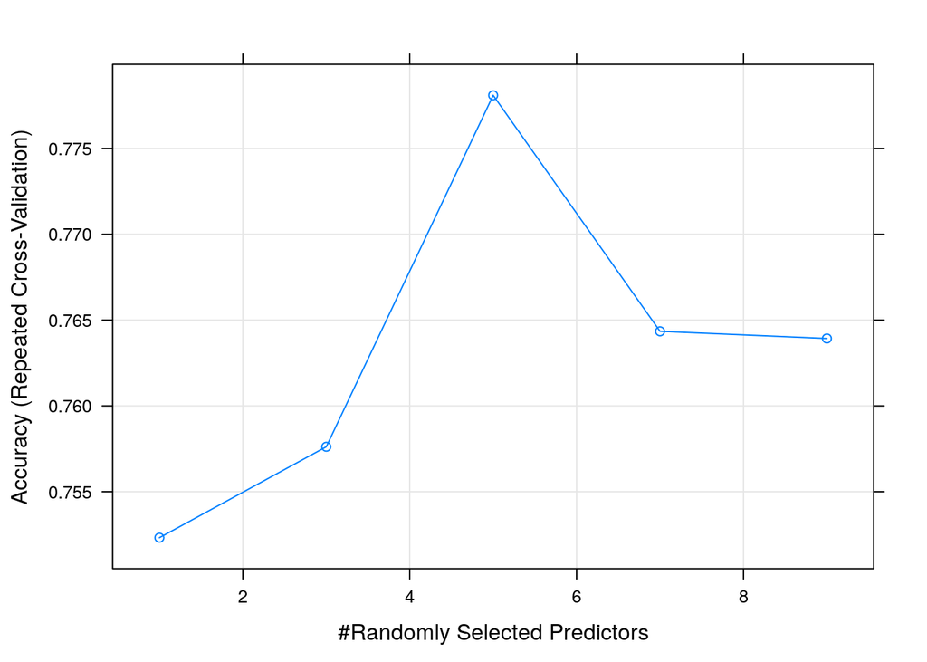

```r
startTimeModule <- proc.time()
set.seed(seedNum)
grid <- expand.grid(mtry = c(1,3,5,7,9))
fit.final1 <- train(targetVar~., data=xy_train, method="rf", metric=metricTarget, tuneGrid=grid, trControl=control)
plot(fit.final1)
```

```r
print(fit.final1)
```

```
## Random Forest
##
## 153 samples
##   9 predictor
##   6 classes: '1', '2', '3', '5', '6', '7'
##
## No pre-processing
## Resampling: Cross-Validated (10 fold, repeated 1 times)
## Summary of sample sizes: 137, 137, 137, 138, 137, 138, ...
## Resampling results across tuning parameters:
##
##   mtry  Accuracy   Kappa
##   1     0.7523214  0.6525179
##   3     0.7576190  0.6638954
##   5     0.7780952  0.6951823
##   7     0.7643452  0.6751800
##   9     0.7639286  0.6760938
##
## Accuracy was used to select the optimal model using the largest value.
## The final value used for the model was mtry = 5.
```

```r
proc.time()-startTimeModule
```

```
##    user  system elapsed
##   3.950   0.010   3.963
```

```r
if (!muteEmail) email_notify(paste("Algorithm #1 tuning completed!",date()))
```

```
## [1] "Java-Object{org.apache.commons.mail.SimpleEmail@548a9f61}"
```

```r
# Tuning algorithm #2 - Gradient Boosting
if (!muteEmail) email_notify(paste("Algorithm #2 tuning has begun!",date()))
```

```
## [1] "Java-Object{org.apache.commons.mail.SimpleEmail@1b604f19}"
```

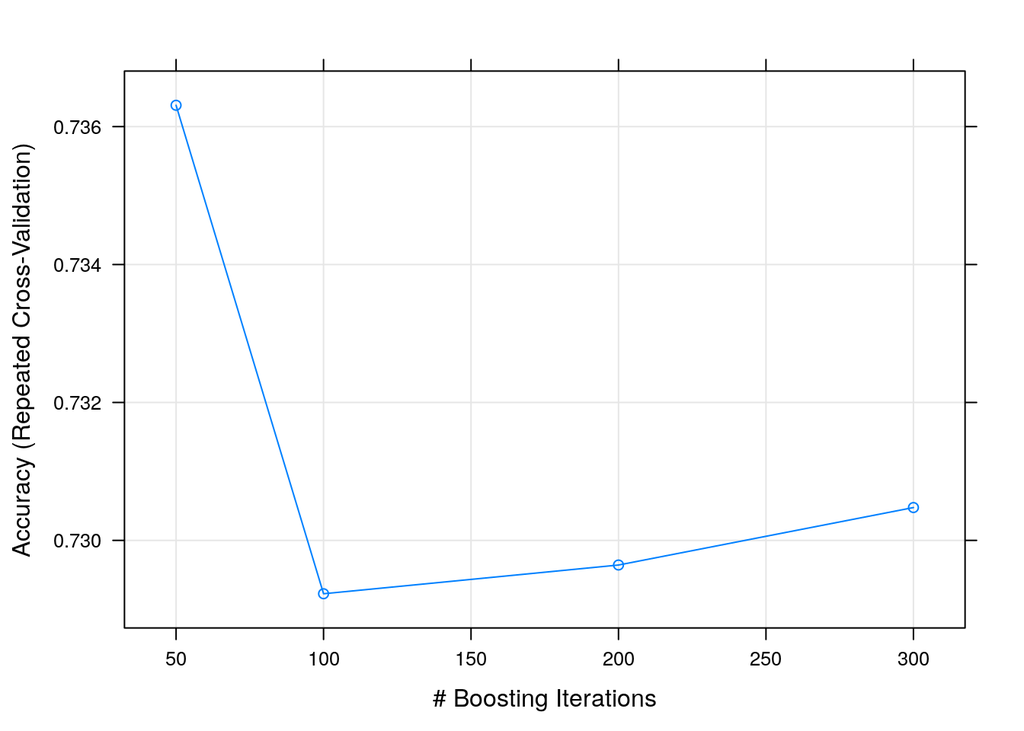

```r
startTimeModule <- proc.time()
set.seed(seedNum)
grid <- expand.grid(nrounds=c(50,100,200,300), max_depth=3, eta=0.3, gamma=0, colsample_bytree=0.8, min_child_weight=1, subsample=0.75)
fit.final2 <- train(targetVar~., data=xy_train, method="xgbTree", metric=metricTarget, tuneGrid=grid, trControl=control, verbose=F)
plot(fit.final2)
```

```r
print(fit.final2)
```

[output not shown]

```r
proc.time()-startTimeModule
```

```
##    user  system elapsed
##   4.010   0.070   2.412
```

```r
if (!muteEmail) email_notify(paste("Algorithm #2 tuning completed!",date()))
```

```
## [1] "Java-Object{org.apache.commons.mail.SimpleEmail@55f3ddb1}"
```

### 5.d) Compare Algorithms After Tuning

```r
results <- resamples(list(RF=fit.final1, XGB=fit.final2))
summary(results)
```

```
##
## Call:
## summary.resamples(object = results)
##
## Models: RF, XGB
## Number of resamples: 10
##
## Accuracy
##          Min.   1st Qu.    Median      Mean 3rd Qu.      Max. NA's
## RF  0.6875000 0.7190476 0.7750000 0.7780952     0.8 0.9333333    0
## XGB 0.5714286 0.6989583 0.7416667 0.7363095     0.8 0.8750000    0
##
## Kappa
##          Min.   1st Qu.    Median      Mean   3rd Qu.      Max. NA's
## RF  0.5744681 0.6127619 0.6818531 0.6951823 0.7351815 0.9107143    0
## XGB 0.3918919 0.5992647 0.6535384 0.6392488 0.7392202 0.8202247    0
```

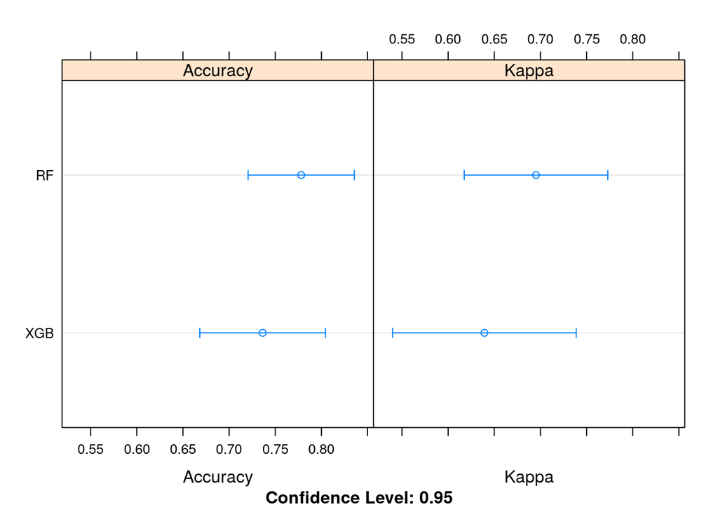

```r
dotplot(results)
```

## 6. Finalize Model and Present Results

Once we have narrow down to a model that we believe can make accurate predictions on unseen data, we are ready to finalize it. Finalizing a model may involve sub-tasks such as:

- Using an optimal model tuned to make predictions on unseen data.
- Creating a standalone model using the tuned parameters
- Saving an optimal model to file for later use.

```r
if (!muteEmail) email_notify(paste("Model Validation and Final Model Creation has begun!",date()))
```

```
## [1] "Java-Object{org.apache.commons.mail.SimpleEmail@46d56d67}"
```

### 6.a) Predictions on validation dataset

```r
predictions <- predict(fit.final1, newdata=xy_test)
confusionMatrix(predictions, y_test)
```

```
## Confusion Matrix and Statistics
##
##           Reference
## Prediction  1  2  3  5  6  7
##          1 19  3  2  0  0  0
##          2  1 17  1  0  1  0
##          3  0  0  2  0  0  0
##          5  0  0  0  2  0  0
##          6  0  1  0  0  1  0
##          7  1  1  0  1  0  8
##
## Overall Statistics
##
##                Accuracy : 0.8033
##                  95% CI : (0.6816, 0.894)
##     No Information Rate : 0.3607
##     P-Value [Acc > NIR] : 1.86e-12
##
##                   Kappa : 0.7257
##
##  Mcnemar's Test P-Value : NA
##
## Statistics by Class:
##
##                      Class: 1 Class: 2 Class: 3 Class: 5 Class: 6 Class: 7
## Sensitivity            0.9048   0.7727  0.40000  0.66667  0.50000   1.0000
## Specificity            0.8750   0.9231  1.00000  1.00000  0.98305   0.9434
## Pos Pred Value         0.7917   0.8500  1.00000  1.00000  0.50000   0.7273
## Neg Pred Value         0.9459   0.8780  0.94915  0.98305  0.98305   1.0000
## Prevalence             0.3443   0.3607  0.08197  0.04918  0.03279   0.1311
## Detection Rate         0.3115   0.2787  0.03279  0.03279  0.01639   0.1311
## Detection Prevalence   0.3934   0.3279  0.03279  0.03279  0.03279   0.1803
## Balanced Accuracy      0.8899   0.8479  0.70000  0.83333  0.74153   0.9717
```

### 6.b) Create standalone model on entire training dataset

```r
startTimeModule <- proc.time()
library(randomForest)
set.seed(seedNum)

# Combining the training and test datasets to form the original dataset that will be used for training the final model
xy_complete <- rbind(xy_train, xy_test)

finalModel <- randomForest(targetVar~., xy_complete, mtry=3, na.action=na.omit)
summary(finalModel)
```

```
##                 Length Class  Mode
## call               5   -none- call
## type               1   -none- character
## predicted        214   factor numeric
## err.rate        3500   -none- numeric
## confusion         42   -none- numeric
## votes           1284   matrix numeric
## oob.times        214   -none- numeric
## classes            6   -none- character
## importance         9   -none- numeric
## importanceSD       0   -none- NULL
## localImportance    0   -none- NULL
## proximity          0   -none- NULL
## ntree              1   -none- numeric
## mtry               1   -none- numeric
## forest            14   -none- list
## y                214   factor numeric
## test               0   -none- NULL
## inbag              0   -none- NULL
## terms              3   terms  call
```

```r
proc.time()-startTimeModule
```

```
##    user  system elapsed
##   0.140   0.000   0.145
```

### 6.c) Save model for later use

```r
#saveRDS(finalModel, "./finalModel_MultiClass.rds")
```

```r
if (!muteEmail) email_notify(paste("Model Validation and Final Model Creation Completed!",date()))
```

```
## [1] "Java-Object{org.apache.commons.mail.SimpleEmail@3532ec19}"
```

```r
proc.time()-startTimeScript
```

```
##    user  system elapsed
##  87.700   2.430  87.965
```